# Customer Segmentation 2

Su Gnee Ng

```r
library(ggplot2)
customer_data=read.csv("Mall_Customers.csv")
str(customer_data)
```

```
## 'data.frame':    200 obs. of  5 variables:
##  $ CustomerID            : int  1 2 3 4 5 6 7 8 9 10 ...
##  $ Gender                : Factor w/ 2 levels "Female","Male": 2 2 1 1 1 1 1 1 2 1 ...
##  $ Age                   : int  19 21 20 23 31 22 35 23 64 30 ...
##  $ Annual.Income..k..    : int  15 15 16 16 17 17 18 18 19 19 ...
##  $ Spending.Score..1.100.: int  39 81 6 77 40 76 6 94 3 72 ...
```

```r
head(customer_data)
```

```
##   CustomerID Gender Age Annual.Income..k.. Spending.Score..1.100.
## 1          1   Male  19                 15                     39
## 2          2   Male  21                 15                     81
## 3          3 Female  20                 16                      6
## 4          4 Female  23                 16                     77
## 5          5 Female  31                 17                     40
## 6          6 Female  22                 17                     76
```

```r
summary(customer_data$Age)
```

```
##    Min. 1st Qu.  Median    Mean 3rd Qu.    Max.
##   18.00   28.75   36.00   38.85   49.00   70.00
```

```r
sex=customer_data$Gender
```

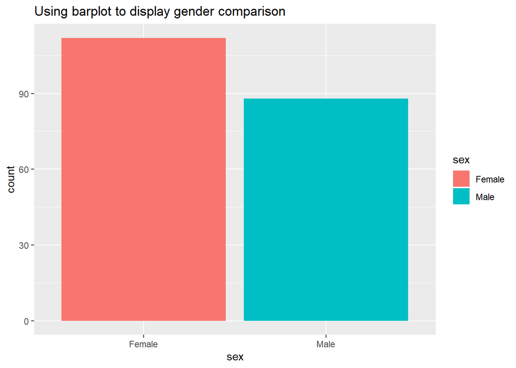

```r
p<-ggplot(data=customer_data, mapping=aes(x=sex,fill=sex))
p+geom_bar()+labs(title="Using barplot to display gender comparison")
```

From the plot, we find that there is a higher number of females than males.

```r
age=customer_data$Age
```

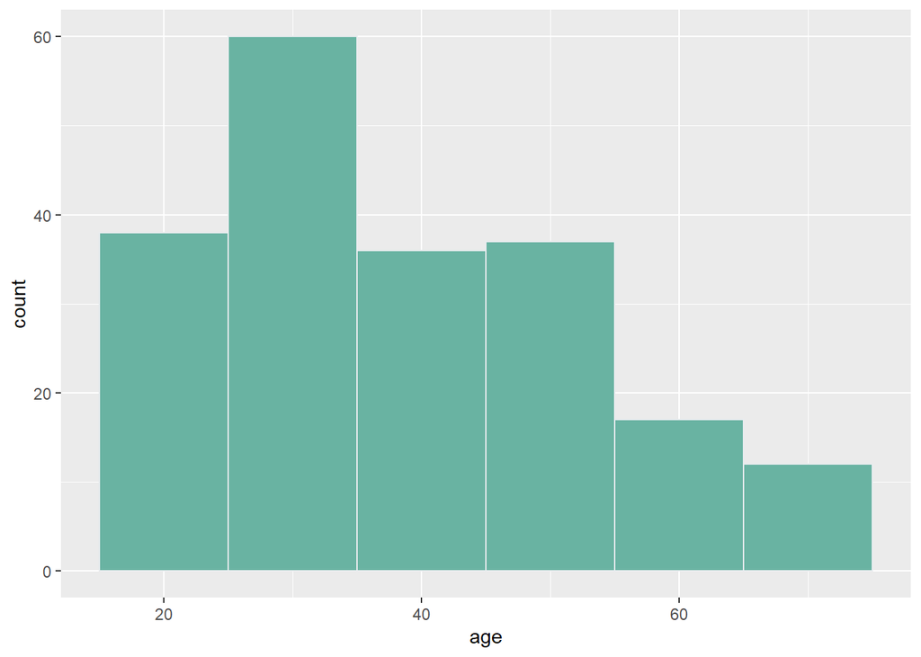

```r
p<-ggplot(data=customer_data, mapping = aes(x=age))
p+geom_histogram(binwidth=10, fill="#69b3a2", color="#e9ecef")
```

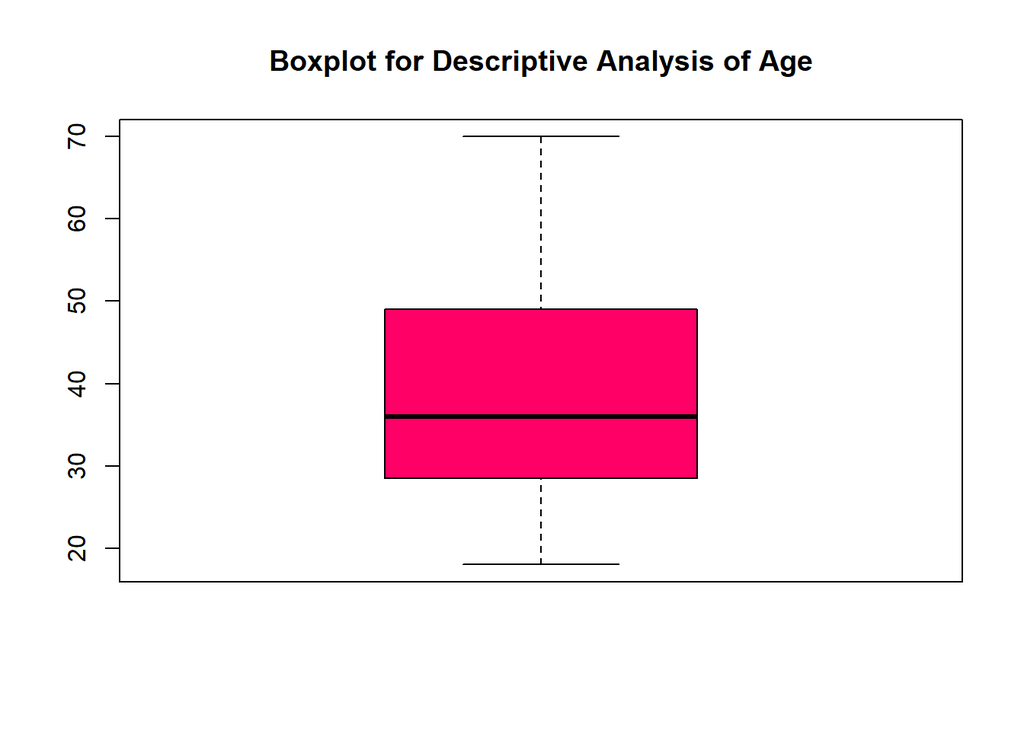

```r
boxplot(customer_data$Age, col="#ff0066", main="Boxplot for Descriptive Analysis of Age")
```

From the above plot the min age is 18 and Max age is 70.

```r
spendingScore=customer_data$Spending.Score..1.100.
summary(spendingScore)
```

```
##    Min. 1st Qu.  Median    Mean 3rd Qu.    Max.
##    1.00   34.75   50.00   50.20   73.00   99.00
```

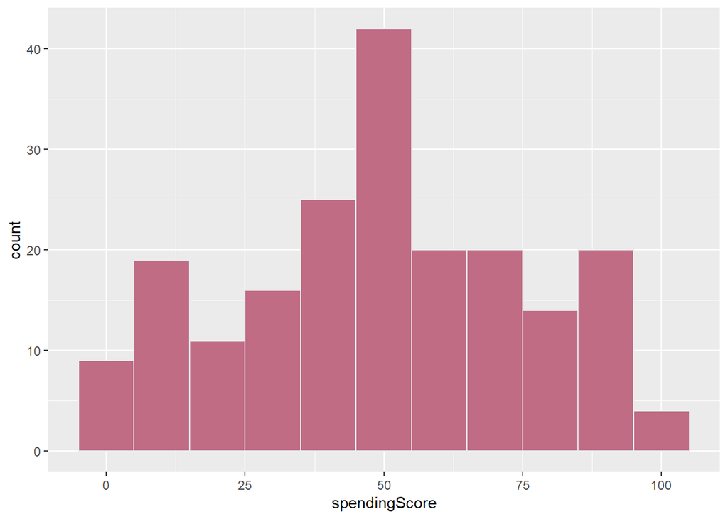

```r
p<-ggplot(data=customer_data, mapping = aes(x=spendingScore))
p+geom_histogram(binwidth=10, fill="#C06C84", color="#e9ecef")
```

```r
income=customer_data$Annual.Income..k..
summary(income)
```

```
##    Min. 1st Qu.  Median    Mean 3rd Qu.    Max.
##   15.00   41.50   61.50   60.56   78.00  137.00
```

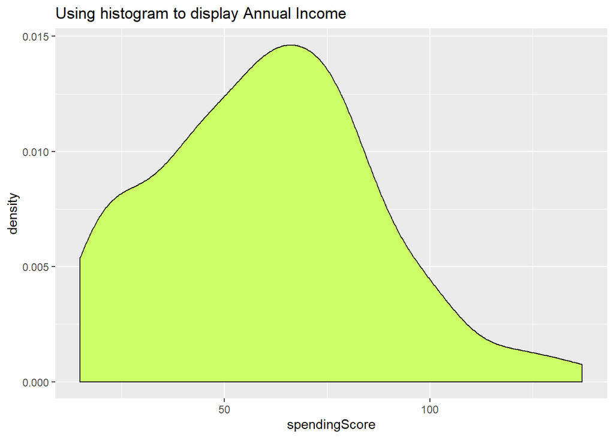

```r
p+geom_density(data=customer_data,mapping=aes(x=income),fill="#ccff66") +labs(title="Using histogram to display Annual Income")
```

we conclude that the minimum annual income of the customers is 15 and the maximum income is 137. People earning an average income of 70 have the highest frequency count in our histogram distribution. The average salary of all the customers is 60.56. In the Kernel Density Plot that we displayed above, we observe that the annual income has a normal distribution.

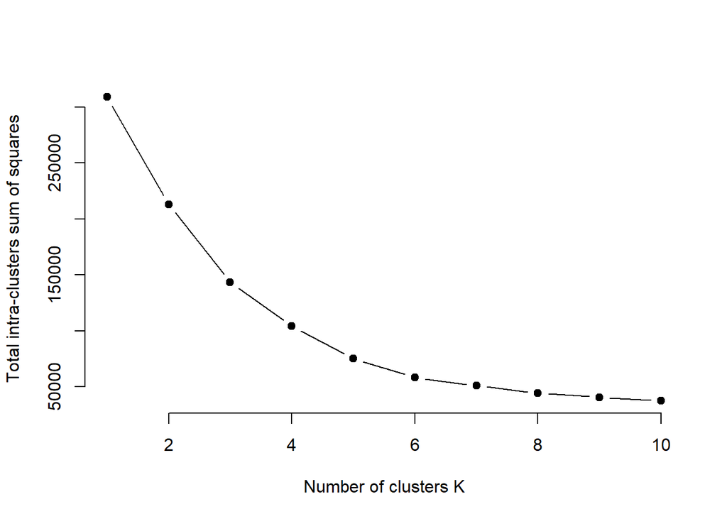

```r
library(purrr)
set.seed(123)
# function to calculate total intra-cluster sum of square
iss <- function(k) {
  kmeans(customer_data[,3:5],k,iter.max=100,nstart=100,algorithm="Lloyd" )$tot.withinss
}

k.values <- 1:10


iss_values <- map_dbl(k.values, iss)

plot(k.values, iss_values,
    type="b", pch = 19, frame = FALSE,
    xlab="Number of clusters K",
    ylab="Total intra-clusters sum of squares")
```

K-means Algorithm is used to calculate the clustering algorithm for several values of k. This is done by creating a variation within k from 1 to 10 clusters. Then we compute total intra-cluster sum of square(iss). We then plot iss based on the number of k clusters. The bend or elbow of the plot indicates the optimal number of clusters. In this plot, 4 is the optimal number of clusters,

```r
k4<-kmeans(customer_data[,3:5],4,iter.max=100,nstart=50,algorithm="Lloyd")
k4
```

```
## K-means clustering with 4 clusters of sizes 95, 28, 39, 38
##
## Cluster means:
##        Age Annual.Income..k.. Spending.Score..1.100.
## 1 44.89474           48.70526               42.63158
## 2 24.82143           28.71429               74.25000
## 3 32.69231           86.53846               82.12821
## 4 40.39474           87.00000               18.63158
##
## Clustering vector:
##   [1] 2 2 1 2 1 2 1 2 1 2 1 2 1 2 1 2 1 2 1 2 1 2 1 2 1 2 1 2 1 2 1 2 1 2 1 2 1
##  [38] 2 1 2 1 2 1 2 1 2 1 1 1 1 1 2 1 1 1 1 1 1 1 1 1 2 1 1 1 2 1 1 2 1 1 1 1 1
##  [75] 1 1 1 1 1 1 1 1 1 1 1 1 1 1 1 1 1 1 1 1 1 1 1 1 1 1 1 1 1 1 1 1 1 1 1 1 1
## [112] 1 1 1 1 1 1 1 1 1 1 1 1 3 4 3 4 3 4 3 4 3 4 3 4 3 4 3 4 3 4 3 4 3 4 3 4 3
## [149] 4 3 4 3 4 3 4 3 4 3 4 3 4 3 4 3 4 3 4 3 4 3 4 3 4 3 4 3 4 3 4 3 4 3 4 3 4
## [186] 3 4 3 4 3 4 3 4 3 4 3 4 3 4 3
##
## Within cluster sum of squares by cluster:
## [1] 62300.800  9099.071 13972.359 18993.921
##  (between_SS / total_SS =  66.2 %)
##
## Available components:
##
## [1] "cluster"      "centers"      "totss"        "withinss"     "tot.withinss"
## [6] "betweenss"    "size"         "iter"         "ifault"
```

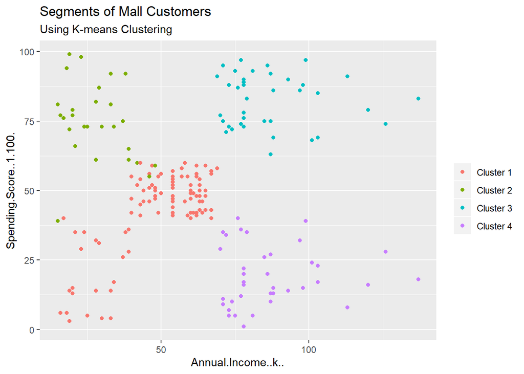

```r
set.seed(1)
ggplot(customer_data, aes(x =Annual.Income..k.., y = Spending.Score..1.100.)) +
  geom_point(stat = "identity", aes(color = as.factor(k4$cluster))) +
  scale_color_discrete(name=" ",
              breaks=c("1", "2", "3", "4"),
              labels=c("Cluster 1", "Cluster 2", "Cluster 3", "Cluster 4")) +
  ggtitle("Segments of Mall Customers", subtitle = "Using K-means Clustering")
```

```r
k6<-kmeans(customer_data[,3:5],6,iter.max=100,nstart=50,algorithm="Lloyd")
k6
```

```
## K-means clustering with 6 clusters of sizes 22, 21, 45, 38, 35, 39
##
## Cluster means:
##        Age Annual.Income..k.. Spending.Score..1.100.
## 1 25.27273           25.72727               79.36364
## 2 44.14286           25.14286               19.52381
## 3 56.15556           53.37778               49.08889
## 4 27.00000           56.65789               49.13158
## 5 41.68571           88.22857               17.28571
## 6 32.69231           86.53846               82.12821
##
## Clustering vector:
##   [1] 2 1 2 1 2 1 2 1 2 1 2 1 2 1 2 1 2 1 2 1 2 1 2 1 2 1 2 1 2 1 2 1 2 1 2 1 2
##  [38] 1 2 1 3 1 3 4 2 1 3 4 4 4 3 4 4 3 3 3 3 3 4 3 3 4 3 3 3 4 3 3 4 4 3 3 3 3
##  [75] 3 4 3 4 4 3 3 4 3 3 4 3 3 4 4 3 3 4 3 4 4 4 3 4 3 4 4 3 3 4 3 4 3 3 3 3 3
## [112] 4 4 4 4 4 3 3 3 3 4 4 4 6 4 6 5 6 5 6 5 6 4 6 5 6 5 6 5 6 5 6 4 6 5 6 5 6
## [149] 5 6 5 6 5 6 5 6 5 6 5 6 5 6 5 6 5 6 5 6 5 6 5 6 5 6 5 6 5 6 5 6 5 6 5 6 5
## [186] 6 5 6 5 6 5 6 5 6 5 6 5 6 5 6
##
## Within cluster sum of squares by cluster:
## [1]  4099.818  7732.381  8062.133  7742.895 16690.857 13972.359
##  (between_SS / total_SS =  81.1 %)
##
## Available components:
##
## [1] "cluster"      "centers"      "totss"        "withinss"     "tot.withinss"
## [6] "betweenss"    "size"         "iter"         "ifault"
```

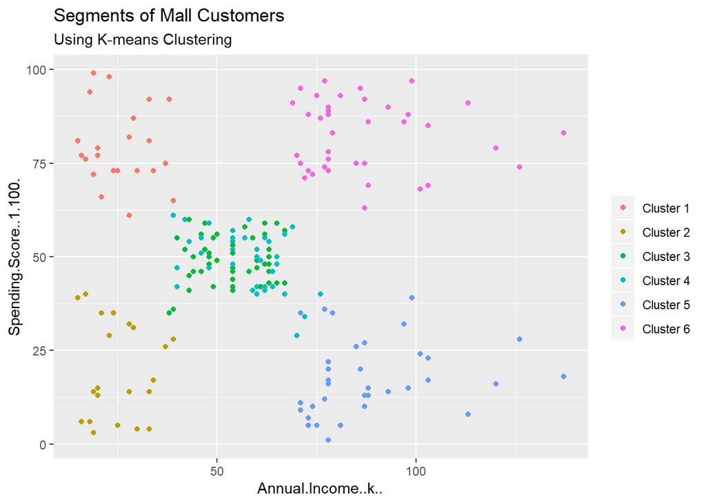

```r
set.seed(1)
ggplot(customer_data, aes(x =Annual.Income..k.., y = Spending.Score..1.100.)) +
  geom_point(stat = "identity", aes(color = as.factor(k6
                                                      $cluster))) +
  scale_color_discrete(name=" ",
              breaks=c("1", "2", "3", "4", "5","6"),
              labels=c("Cluster 1", "Cluster 2", "Cluster 3", "Cluster 4", "Cluster 5","Cluster 6")) +
  ggtitle("Segments of Mall Customers", subtitle = "Using K-means Clustering")
```

From the visualization we observe that there is a distribution of 6 clusters, as follows:

Cluster 3,4- customers with medium income and medium spending

Cluster 5- cutomers with high income and low spending power

Cluter 2- customers with low income and low spending power

Cluster 1- customers with low income and high spending power

Cluster 6- customers with high income and high spending power